# Demo Using RplotterPkg::multi_panel_grid()

Rick Dean

12/15/2019

```r
library(knitr)
library(grid)
library(gtable)
library(dplyr)
```

```r
library(ggplot2)
library(RplotterPkg)
```

# 1 The data

Will be using ggplot2::midwest –

```r
glimpse(ggplot2::midwest)
```

```
## Rows: 437
## Columns: 28
## $ PID                  <int> 561, 562, 563, 564, 565, 566, 567, 568, 569, 5...
## $ county               <chr> "ADAMS", "ALEXANDER", "BOND", "BOONE", "BROWN"...
## $ state                <chr> "IL", "IL", "IL", "IL", "IL", "IL", "IL", "IL"...
## $ area                 <dbl> 0.052, 0.014, 0.022, 0.017, 0.018, 0.050, 0.01...
## $ poptotal             <int> 66090, 10626, 14991, 30806, 5836, 35688, 5322,...
## $ popdensity           <dbl> 1270.9615, 759.0000, 681.4091, 1812.1176, 324....
## $ popwhite             <int> 63917, 7054, 14477, 29344, 5264, 35157, 5298, ...
## $ popblack             <int> 1702, 3496, 429, 127, 547, 50, 1, 111, 16, 165...
## $ popamerindian        <int> 98, 19, 35, 46, 14, 65, 8, 30, 8, 331, 51, 26,...
## $ popasian             <int> 249, 48, 16, 150, 5, 195, 15, 61, 23, 8033, 89...
## $ popother             <int> 124, 9, 34, 1139, 6, 221, 0, 84, 6, 1596, 20, ...
## $ percwhite            <dbl> 96.71206, 66.38434, 96.57128, 95.25417, 90.198...
## $ percblack            <dbl> 2.57527614, 32.90043290, 2.86171703, 0.4122573...
## $ percamerindan        <dbl> 0.14828264, 0.17880670, 0.23347342, 0.14932156...
## $ percasian            <dbl> 0.37675897, 0.45172219, 0.10673071, 0.48691813...
## $ percother            <dbl> 0.18762294, 0.08469791, 0.22680275, 3.69733169...
## $ popadults            <int> 43298, 6724, 9669, 19272, 3979, 23444, 3583, 1...
## $ perchsd              <dbl> 75.10740, 59.72635, 69.33499, 75.47219, 68.861...
## $ percollege           <dbl> 19.63139, 11.24331, 17.03382, 17.27895, 14.476...
## $ percprof             <dbl> 4.355859, 2.870315, 4.488572, 4.197800, 3.3676...
## $ poppovertyknown      <int> 63628, 10529, 14235, 30337, 4815, 35107, 5241,...
## $ percpovertyknown     <dbl> 96.27478, 99.08714, 94.95697, 98.47757, 82.505...
## $ percbelowpoverty     <dbl> 13.151443, 32.244278, 12.068844, 7.209019, 13....
## $ percchildbelowpovert <dbl> 18.011717, 45.826514, 14.036061, 11.179536, 13...
## $ percadultpoverty     <dbl> 11.009776, 27.385647, 10.852090, 5.536013, 11....
## $ percelderlypoverty   <dbl> 12.443812, 25.228976, 12.697410, 6.217047, 19....
## $ inmetro              <int> 0, 0, 0, 1, 0, 0, 0, 0, 0, 1, 0, 0, 0, 1, 0, 1...
## $ category             <chr> "AAR", "LHR", "AAR", "ALU", "AAR", "AAR", "LAR...
```

# 2 Define a data frame

Task: Create a data frame that focuses on the percent of child poverty across 5 midwest states and their counties.

```r
child_poverty_df <- ggplot2::midwest %>%
  select(state, county, perchsd, percchildbelowpovert) %>%
  mutate(state = factor(state)) %>%
  rename(State = state, High_School = perchsd, Child_Poverty = percchildbelowpovert) %>%
  arrange(desc(Child_Poverty))
glimpse(child_poverty_df)
```

```
## Rows: 437
## Columns: 4
## $ State         <fct> WI, IL, IL, MI, OH, OH, IL, MI, IL, OH, OH, OH, MI, O...
## $ county        <chr> "MENOMINEE", "ALEXANDER", "PULASKI", "LAKE", "SCIOTO"...
## $ High_School   <dbl> 62.69511, 59.72635, 59.77990, 61.28815, 63.75691, 60....
## $ Child_Poverty <dbl> 64.30848, 45.82651, 40.03742, 37.69860, 37.65237, 36....
```

# 3 Summarize the data

Task: Summarize the child poverty across the states by creating a graphic summary table.

Note: We just need the summary table’s *grob* and not display it yet.

```r
child_poverty_summary_df <- child_poverty_df %>%
  group_by(State) %>%
  summarise(
    N = n(),
    Mean_Child_Poverty = round(mean(Child_Poverty), 2)
  ) %>%
  arrange(desc(Mean_Child_Poverty))

child_poverty_table <- RplotterPkg::create_table_graphic(
  df = child_poverty_summary_df,
  table_width = 8,
  title = "Mean Percent of Child Poverty Across Midwest Counties",
  show_row_names = FALSE,
  display_plot = FALSE
)
```

# 4 Plotting a relationship

Task: Plot the relationship between percent having a high school diploma and child poverty for counties across the 5 states.

```r
poverty_plot <-RplotterPkg::multi_scatter_plot(
  df = child_poverty_df,
  columns = 5,
  factor_var = "State",
  factor_x = "High_School",
  aes_y = "Child_Poverty",
  x_title = "% High School Diploma",
  x_limits = c(40,90),
  x_major_breaks = seq(40,90,5),
  y_limits = c(0,60),
  y_major_breaks = seq(0,60,10),
  show_minor_grids = FALSE,
  col_width = 3,
  row_height = 3,
  display_plot = FALSE,
  silent_NA_warning = TRUE
)
```

# 5 Combine table, plot, and text

Task: Use RplotterPkg::multi_panel_grid() to combine the above table, factor plot, and some text in a single layout.

1. Create the text grob:

```r
caption_text_grob <- grid::textGrob(label = "There appears to be a relationship between adult education and child poverty", gp = grid::gpar(col = "black", fontsize = 14, fontface = 2))
```

2. Create the layout. The *layout* argument of `multi_panel_grid()` is a named list defined as follows:

```r
layout <- list(
  plots = list(child_poverty_table, poverty_plot, caption_text_grob), # plot/grob objects to display
  rows = c(1, 2, 3), # each plot/grob will be on a separate row
  cols = c(list(1:2), list(1:3), list(1:2)) # the table spans columns 1 to 2; the plot spans columns 1 to 3; the caption spans columns 1 to 2;
)
```

3. We have 3 columns and 3 rows. Define (in inches) the width of the columns and heights of the rows:

```r
col_widths <- c(5, 5, 5) # divide the grid in columns of 5 inches
row_heights <- c(3.5, 3.4, .5) # table is 3.5 inches hight; plot is 3.4 inches hight; caption is .5 inch high
```

Enter the above arguments to `RplotterPkg::multi_panel_grid()` and display the combined figure:

Note: The argument *display_plot* is by default *TRUE* for `multi_panel_grid()`

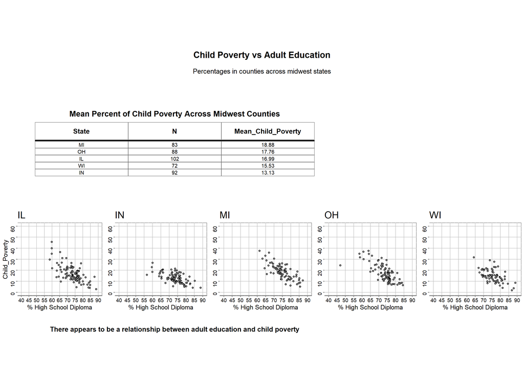

```r
poverty_figure <- RplotterPkg::multi_panel_grid(
  layout = layout,
  col_widths = col_widths,
  row_heights = row_heights,
  title = "Child Poverty vs Adult Education",
  subtitle = "Percentages in counties across midwest states"
)
```